# Cohort 2023 Homework 1

## Jaicnto Jimenez

### data-engineering-zoomcamp cohorts 2023

### Week 1 Homework

### In this homework we'll prepare the environment and practice with Docker and SQL

## Question 1. Knowing docker tags

Run the command to get information on Docker

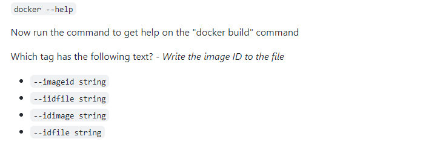

The tag for the command to write the image ID to a file is "--iidfile string"

You can run the command "docker build --help" to get more information on the available options and tags for the "docker build" command.

## Question 2. Understanding docker first run

Run docker with the python:3.9 image in an interactive mode and the entrypoint of bash. Now check the python modules that are installed ( use pip list). How many python packages/modules are installed?

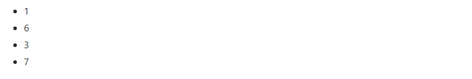

It appears that there are 3 python packages/modules installed in the container: pip, setuptools, and wheel.

## Prepare Postgres

```python
import pandas as pd
from sqlalchemy import create_engine
from time import time
import time
```

Prepare Postgres

Run Postgres and load data as shown in the videos We'll use the green taxi trips from January 2019:

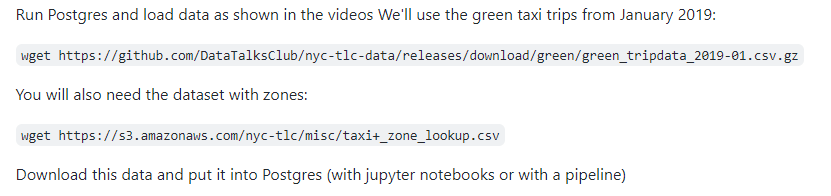

```python
# Know we are asked to download the green taxi trips form january 2019
df_green_taxi = pd.read_csv('green_tripdata_2019-01.csv', nrows=100)
```

```python
df_green_taxi
```

|  | VendorID | lpep_pickup_datetime | lpep_dropoff_datetime | store_and_fwd_flag | RatecodeID | PULocationID | DOLocationID | passenger_count | trip_distance | fare_amount | extra | mta_tax | tip_amount | tolls_amount | ehail_fee | improvement_surcharge | total_amount | payment_type | trip_type | congestion_surcharge |
| --- | --- | --- | --- | --- | --- | --- | --- | --- | --- | --- | --- | --- | --- | --- | --- | --- | --- | --- | --- | --- |
| 0 | 2 | 2018-12-21 15:17:29 | 2018-12-21 15:18:57 | N | 1 | 264 | 264 | 5 | 0.00 | 3.0 | 0.5 | 0.5 | 0.00 | 0.0 | NaN | 0.3 | 4.30 | 2 | 1 | NaN |
| 1 | 2 | 2019-01-01 00:10:16 | 2019-01-01 00:16:32 | N | 1 | 97 | 49 | 2 | 0.86 | 6.0 | 0.5 | 0.5 | 0.00 | 0.0 | NaN | 0.3 | 7.30 | 2 | 1 | NaN |
| 2 | 2 | 2019-01-01 00:27:11 | 2019-01-01 00:31:38 | N | 1 | 49 | 189 | 2 | 0.66 | 4.5 | 0.5 | 0.5 | 0.00 | 0.0 | NaN | 0.3 | 5.80 | 1 | 1 | NaN |
| 3 | 2 | 2019-01-01 00:46:20 | 2019-01-01 01:04:54 | N | 1 | 189 | 17 | 2 | 2.68 | 13.5 | 0.5 | 0.5 | 2.96 | 0.0 | NaN | 0.3 | 19.71 | 1 | 1 | NaN |
| 4 | 2 | 2019-01-01 00:19:06 | 2019-01-01 00:39:43 | N | 1 | 82 | 258 | 1 | 4.53 | 18.0 | 0.5 | 0.5 | 0.00 | 0.0 | NaN | 0.3 | 19.30 | 2 | 1 | NaN |
| ... | ... | ... | ... | ... | ... | ... | ... | ... | ... | ... | ... | ... | ... | ... | ... | ... | ... | ... | ... | ... |
| 95 | 2 | 2019-01-01 00:15:42 | 2019-01-01 00:41:04 | N | 1 | 97 | 179 | 1 | 7.83 | 26.0 | 0.5 | 0.5 | 5.46 | 0.0 | NaN | 0.3 | 32.76 | 1 | 1 | NaN |
| 96 | 2 | 2019-01-01 00:21:28 | 2019-01-01 00:48:15 | N | 1 | 7 | 230 | 1 | 4.49 | 20.0 | 0.5 | 0.5 | 4.00 | 0.0 | NaN | 0.3 | 25.30 | 1 | 1 | NaN |
| 97 | 2 | 2019-01-01 00:17:10 | 2019-01-01 00:23:34 | N | 1 | 42 | 42 | 1 | 1.08 | 6.5 | 0.5 | 0.5 | 0.00 | 0.0 | NaN | 0.3 | 7.80 | 2 | 1 | NaN |
| 98 | 2 | 2019-01-01 00:25:01 | 2019-01-01 00:43:55 | N | 1 | 42 | 232 | 2 | 8.74 | 25.0 | 0.5 | 0.5 | 0.00 | 0.0 | NaN | 0.3 | 26.30 | 2 | 1 | NaN |
| 99 | 2 | 2019-01-01 00:36:56 | 2019-01-01 00:43:50 | N | 1 | 223 | 7 | 5 | 1.32 | 7.0 | 0.5 | 0.5 | 2.00 | 0.0 | NaN | 0.3 | 10.30 | 1 | 1 | NaN |

100 rows × 20 columns

```python
engine = create_engine('postgresql://root:admin@localhost:5432/ny_taxi')
```

```python
#we need to know th
print(pd.io.sql.get_schema(df_green_taxi, name='green_taxi_data', con=engine))
```

```
CREATE TABLE green_taxi_data (
	"VendorID" BIGINT,
	lpep_pickup_datetime TEXT,
	lpep_dropoff_datetime TEXT,
	store_and_fwd_flag TEXT,
	"RatecodeID" BIGINT,
	"PULocationID" BIGINT,
	"DOLocationID" BIGINT,
	passenger_count BIGINT,
	trip_distance FLOAT(53),
	fare_amount FLOAT(53),
	extra FLOAT(53),
	mta_tax FLOAT(53),
	tip_amount FLOAT(53),
	tolls_amount FLOAT(53),
	ehail_fee FLOAT(53),
	improvement_surcharge FLOAT(53),
	total_amount FLOAT(53),
	payment_type BIGINT,
	trip_type BIGINT,
	congestion_surcharge FLOAT(53)
)
```

```python
df_green_taxi.head(n=0).to_sql(name='green_taxi_data',con=engine, if_exists='replace')
```

```
0
```

```python
# lpep_pickup_datetime TEXT,  and lpep_dropoff_datetime TEXT, are text we need to conver to date type
df_green_taxi = pd.read_csv('green_tripdata_2019-01.csv')
engine = create_engine('postgresql://root:admin@localhost:5432/ny_taxi')
```

```python
# Read the dataframe
df = pd.read_csv('green_tripdata_2019-01.csv')

# Use the head(n=0) to create an empty dataframe
df_empty = df.head(n=0)

# Use to_sql() method to create the table in the database
df_empty.to_sql(name='green_taxi_data', con=engine, if_exists='replace')
```

```
0
```

```python
# we need to convert and data to the database gree taxi 2019

start_time = time.time()

#create an iterator for the dataframe
df_iter = pd.read_csv('green_tripdata_2019-01.csv', iterator=True ,  chunksize=100000)

#iterate through the chunks
for i, df in enumerate(df_iter):
    #convert datetime columns to datetime objects
    df.lpep_pickup_datetime = pd.to_datetime(df.lpep_pickup_datetime)
    df.lpep_dropoff_datetime = pd.to_datetime(df.lpep_dropoff_datetime)

    #append the data to the database
    df.to_sql(name='green_taxi_data',con=engine, if_exists='append')

    #print the time taken for each chunk
    print(f'Inserted chunk {i+1}. Time taken: {time.time() - start_time:.3f} seconds')
```

```
Inserted chunk 1. Time taken: 14.415 seconds
Inserted chunk 2. Time taken: 29.857 seconds
Inserted chunk 3. Time taken: 44.726 seconds
Inserted chunk 4. Time taken: 62.898 seconds
Inserted chunk 5. Time taken: 77.556 seconds
Inserted chunk 6. Time taken: 92.764 seconds
Inserted chunk 7. Time taken: 98.588 seconds
```

You will also need the dataset with zones:

wget https://s3.amazonaws.com/nyc-tlc/misc/taxi+_zone_lookup.csv

```python
# Know we are asked to download the green taxi trips form january 2019
df_zones = pd.read_csv('https://s3.amazonaws.com/nyc-tlc/misc/taxi+_zone_lookup.csv', nrows=100)
#we need to know the
print(pd.io.sql.get_schema(df_zones, name='zones', con=engine))
```

```
CREATE TABLE zones (
	"LocationID" BIGINT,
	"Borough" TEXT,
	"Zone" TEXT,
	service_zone TEXT
)
```

```python
# we need to the code for the zones

df_zones = pd.read_csv('taxi+_zone_lookup.csv')
```

```python
df_zones.head(n=0).to_sql(name='zones',con=engine, if_exists='replace')
```

```
0
```

```python
# we need to convert and data to the database gree taxi 2019

start_time = time.time()

#create an iterator for the dataframe
df_iter = pd.read_csv('taxi+_zone_lookup.csv', iterator=True ,  chunksize=100000)

#iterate through the chunks
for i, df in enumerate(df_iter):
    #append the data to the database
    df.to_sql(name='zones',con=engine, if_exists='append')

    #print the time taken for each chunk
    print(f'Inserted chunk {i+1}. Time taken: {time.time() - start_time:.3f} seconds')
```

```
Inserted chunk 1. Time taken: 0.405 seconds
```

```python
# Know we are asked to download the green taxi trips form january 2019
df_yellow_taxi = pd.read_csv('yellow_tripdata_2021-01.csv', nrows=100)
```

```python
df_yellow_taxi
```

|  | VendorID | tpep_pickup_datetime | tpep_dropoff_datetime | passenger_count | trip_distance | RatecodeID | store_and_fwd_flag | PULocationID | DOLocationID | payment_type | fare_amount | extra | mta_tax | tip_amount | tolls_amount | improvement_surcharge | total_amount | congestion_surcharge |
| --- | --- | --- | --- | --- | --- | --- | --- | --- | --- | --- | --- | --- | --- | --- | --- | --- | --- | --- |
| 0 | 1 | 2021-01-01 00:30:10 | 2021-01-01 00:36:12 | 1 | 2.10 | 1 | N | 142 | 43 | 2 | 8.0 | 3.0 | 0.5 | 0.00 | 0.0 | 0.3 | 11.80 | 2.5 |
| 1 | 1 | 2021-01-01 00:51:20 | 2021-01-01 00:52:19 | 1 | 0.20 | 1 | N | 238 | 151 | 2 | 3.0 | 0.5 | 0.5 | 0.00 | 0.0 | 0.3 | 4.30 | 0.0 |
| 2 | 1 | 2021-01-01 00:43:30 | 2021-01-01 01:11:06 | 1 | 14.70 | 1 | N | 132 | 165 | 1 | 42.0 | 0.5 | 0.5 | 8.65 | 0.0 | 0.3 | 51.95 | 0.0 |
| 3 | 1 | 2021-01-01 00:15:48 | 2021-01-01 00:31:01 | 0 | 10.60 | 1 | N | 138 | 132 | 1 | 29.0 | 0.5 | 0.5 | 6.05 | 0.0 | 0.3 | 36.35 | 0.0 |
| 4 | 2 | 2021-01-01 00:31:49 | 2021-01-01 00:48:21 | 1 | 4.94 | 1 | N | 68 | 33 | 1 | 16.5 | 0.5 | 0.5 | 4.06 | 0.0 | 0.3 | 24.36 | 2.5 |
| ... | ... | ... | ... | ... | ... | ... | ... | ... | ... | ... | ... | ... | ... | ... | ... | ... | ... | ... |
| 95 | 2 | 2021-01-01 00:12:41 | 2021-01-01 00:26:47 | 1 | 4.13 | 1 | N | 161 | 226 | 1 | 14.5 | 0.5 | 0.5 | 3.66 | 0.0 | 0.3 | 21.96 | 2.5 |
| 96 | 2 | 2021-01-01 00:23:29 | 2021-01-01 00:35:03 | 2 | 4.12 | 1 | N | 162 | 74 | 2 | 13.5 | 0.5 | 0.5 | 0.00 | 0.0 | 0.3 | 17.30 | 2.5 |
| 97 | 2 | 2021-01-01 00:46:17 | 2021-01-01 00:54:25 | 2 | 2.22 | 1 | N | 144 | 170 | 1 | 9.0 | 0.5 | 0.5 | 2.56 | 0.0 | 0.3 | 15.36 | 2.5 |
| 98 | 2 | 2021-01-01 00:28:16 | 2021-01-01 00:51:44 | 1 | 7.11 | 1 | N | 264 | 264 | 2 | 23.5 | 0.5 | 0.5 | 0.00 | 0.0 | 0.3 | 24.80 | 0.0 |
| 99 | 2 | 2021-01-01 00:42:35 | 2021-01-01 00:54:41 | 3 | 1.61 | 1 | N | 229 | 237 | 2 | 9.5 | 0.5 | 0.5 | 0.00 | 0.0 | 0.3 | 13.30 | 2.5 |

100 rows × 18 columns

```python
# Know we are asked to download the green taxi trips form january 2019
df_yellow_taxi = pd.read_csv('yellow_tripdata_2021-01.csv', nrows=100)
#we need to know the
print(pd.io.sql.get_schema(df_yellow_taxi, name='yellow_tripdata_trips', con=engine))
```

```
CREATE TABLE yellow_tripdata_trips (
	"VendorID" BIGINT,
	tpep_pickup_datetime TEXT,
	tpep_dropoff_datetime TEXT,
	passenger_count BIGINT,
	trip_distance FLOAT(53),
	"RatecodeID" BIGINT,
	store_and_fwd_flag TEXT,
	"PULocationID" BIGINT,
	"DOLocationID" BIGINT,
	payment_type BIGINT,
	fare_amount FLOAT(53),
	extra FLOAT(53),
	mta_tax FLOAT(53),
	tip_amount FLOAT(53),
	tolls_amount FLOAT(53),
	improvement_surcharge FLOAT(53),
	total_amount FLOAT(53),
	congestion_surcharge FLOAT(53)
)
```

```python
# Read the dataframe
df = pd.read_csv('yellow_tripdata_2021-01.csv', nrows=100)

# Use the head(n=0) to create an empty dataframe
df_empty = df.head(n=0)

# Use to_sql() method to create the table in the database
df_empty.to_sql(name='yellow_tripdata_trips', con=engine, if_exists='replace')
```

```
0
```

```python
start_time = time.time()

#create an iterator for the dataframe
df_iter = pd.read_csv('yellow_tripdata_2021-01.csv', iterator=True ,  chunksize=100000)

#iterate through the chunks
for i, df in enumerate(df_iter):
    #convert datetime columns to datetime objects
    df.tpep_pickup_datetime = pd.to_datetime(df.tpep_pickup_datetime)
    df.tpep_dropoff_datetime = pd.to_datetime(df.tpep_dropoff_datetime)

    #append the data to the database
    df.to_sql(name='yellow_tripdata_trips',con=engine, if_exists='append')

    #print the time taken for each chunk
    print(f'Inserted chunk {i+1}. Time taken: {time.time() - start_time:.3f} seconds')
```

```
Inserted chunk 1. Time taken: 12.289 seconds
Inserted chunk 2. Time taken: 25.866 seconds
Inserted chunk 3. Time taken: 40.850 seconds
Inserted chunk 4. Time taken: 54.576 seconds
Inserted chunk 5. Time taken: 68.998 seconds
Inserted chunk 6. Time taken: 83.909 seconds
Inserted chunk 7. Time taken: 98.092 seconds
Inserted chunk 8. Time taken: 111.472 seconds
Inserted chunk 9. Time taken: 126.805 seconds
Inserted chunk 10. Time taken: 139.623 seconds
Inserted chunk 11. Time taken: 152.797 seconds
Inserted chunk 12. Time taken: 167.318 seconds
```

```
Inserted chunk 13. Time taken: 179.654 seconds
Inserted chunk 14. Time taken: 188.366 seconds
```

## Question 3. Count records

How many taxi trips were totally made on January 15?

Tip: started and finished on 2019-01-15.

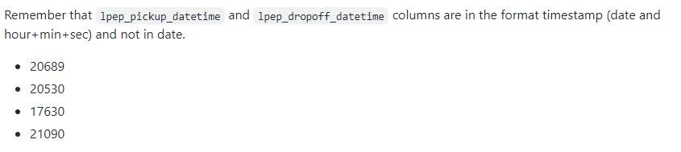

To count the number of taxi trips that were started and finished on January 15, 2019, you can use the following query:

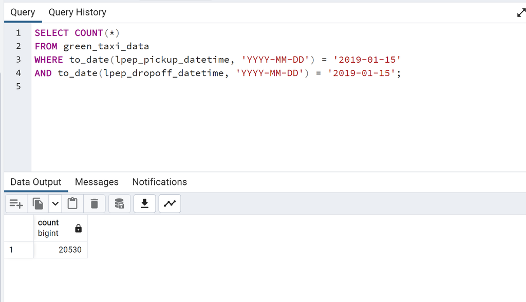

This query uses the to_date() function to convert the lpep_pickup_datetime and lpep_dropoff_datetime columns to date data types, and then filters the table to only include rows where both the pickup and dropoff date are equal to January 15, 2019. The COUNT(*) function is then used to count the number of remaining rows.

## Question 4. Largest trip for each day

Which was the day with the largest trip distance Use the pick up time for your calculations.

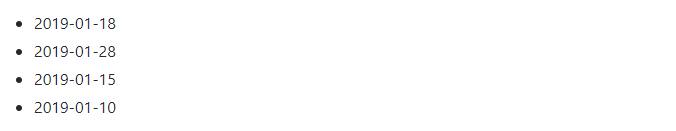

To determine the day with the largest trip distance, you can use the following query:

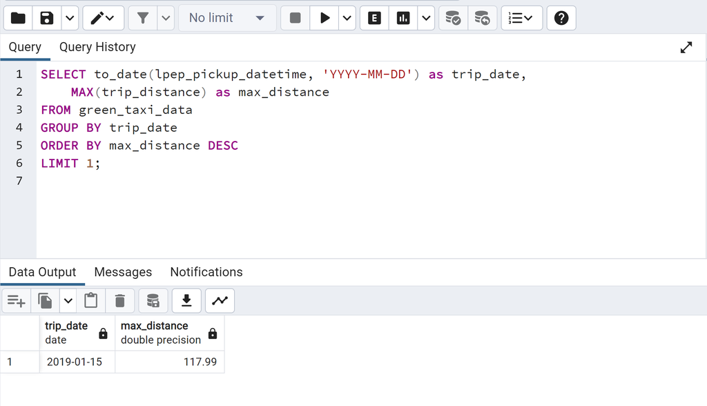

This query uses the to_date() function to convert the lpep_pickup_datetime column to a date data type, and then groups the data by the trip_date column. The MAX() function is then used to determine the maximum trip distance for each group. The query then orders the result set by max_distance in descending order and returns the first row of the result set which will have the day with the largest trip distance.

## Question 5. The number of passengers

In 2019-01-01 how many trips had 2 and 3 passengers?

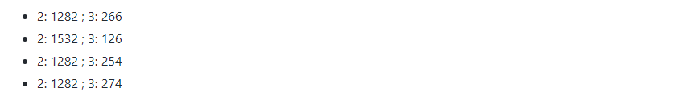

To determine the number of trips that had 2 and 3 passengers on January 1, 2019, with the output format you provided, you can use the following query:

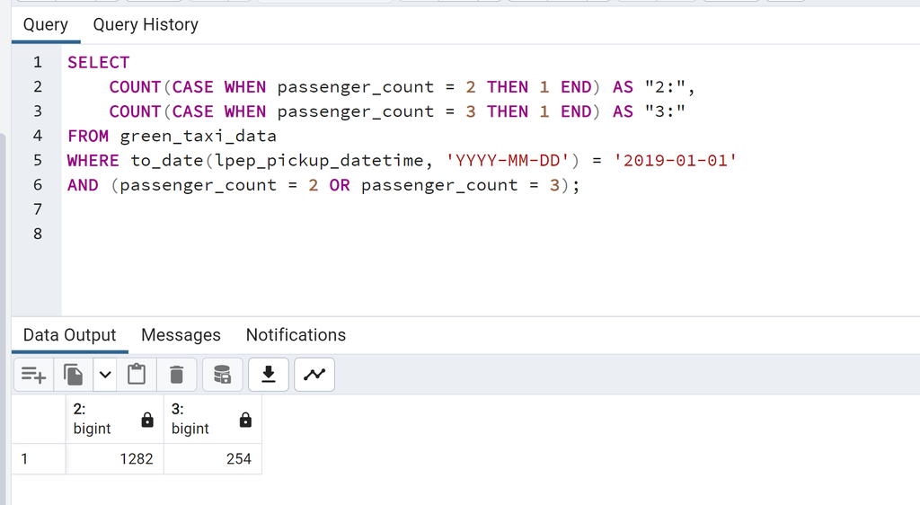

## Question 6. Largest tip

For the passengers picked up in the Astoria Zone which was the drop off zone that had the largest tip? We want the name of the zone, not the id.

Note: it's not a typo, it's tip , not trip

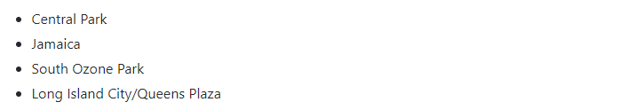

Here is the qurey

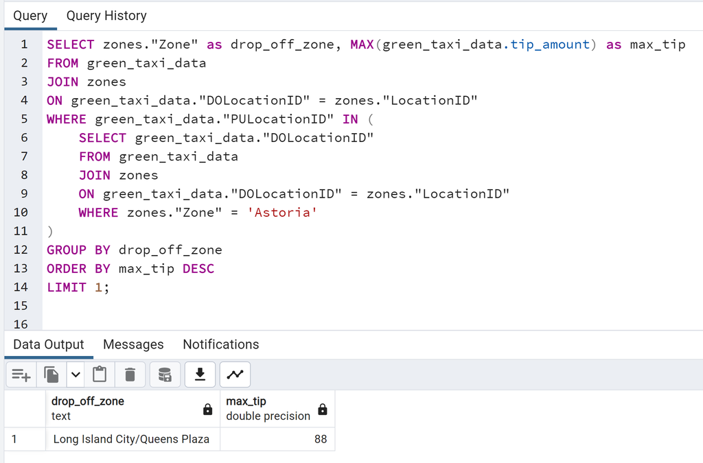

Here is a breakdown of what the query is doing:

It selects the columns "zones.zone as drop_off_zone" and "MAX(green_taxi_data.tip_amount) as max_tip" from the green_taxi_data table. It joins the green_taxi_data table with the zones table on the common column "DOLocationID" It filters the rows where the pickup zone is 'Astoria' by using a subquery and IN operator to check if the pickup location id exists in the subquery result. It groups the data by the drop_off_zone column It orders the result set by max_tip in descending order It limits the result to 1 row. So, this query will give you the drop off zone that had the largest tip for passengers picked up in the Astoria Zone. Please let me know if you have any further question.